# Working with survey data

# Survey Data

1. Import/cleanup
2. Analysis

## Data source: the American National Election Study

ANES Time-Series study:

- One round every 4 years. Respondents are given a pre-election and post-election survey.
- Many questions are repeated over several rounds, allowing for long-running time cross sectional time series (the cumulative time series goes back to 1948)

### ANES Survey modes

- Face-to-Face, phone, online and pen-and-paper modes.
- A subset of 2024 respondents were part of a panel - meaning they were also surveyed in 2016/2020.

Number of respondents and survey modes for 2024 ANES

|  |  | N | % |
| --- | --- | --- | --- |
| Pre-Election mode | 1. Face-to-face (FTF) | 966 | 17 |
|  | 2. Internet (WEB) | 4234 | 77 |
|  | 3. Paper (PAPI) | 245 | 4 |
|  | 4. Phone | 76 | 1 |
| Post-Election mode | No follow-up | 557 | 10 |
|  | 1. Face-to-face (FTF) | 354 | 6 |
|  | 2. Internet (WEB) | 3839 | 70 |
|  | 3. Paper (PAPI) | 200 | 4 |
|  | 4. Phone | 227 | 4 |
|  | 5. Video | 344 | 6 |

### ANES Sampling strategy

ANES uses multi-stage stratified clustering. The precise details vary from one round to the next, but the general idea is:

1. Stratify the country into areas (based on things that are correlated with survey variables like turnout/partisanship)
2. For *all* strata: sample some number of counties/metro areas
3. Within each selected area: sample some number of census blocks
4. Within each selected block: sample some number of households
5. Within each selected household: sample a voting age adult

[figure not shown]

### Try it out

Head over to https://electionstudies.org/data-center/ and download the 2024 time series study. Select the `STATA` format and then place the files in your GVPT 628 project in a folder called “Data”

If you have `here` and `haven` installed, you can run the code below to locate the file and import it:

```r
library(tidyverse)
library(haven)
file<-here::here('Data/anes_timeseries_2024_stata_20260519.zip')
anes24<-read_dta(unz(file,'anes_timeseries_2024_stata_20260519.dta'))
```

# Data import and clean-up

Not necessarily unique to survey data, but more common here:

- Most surveys have complex response categories that often require re-coding
- Many surveys will use data formats that include a “label” attribute that R doesn’t natively support
  - These may have special values for different kinds of non-response (NA vs. “skipped” vs. refused)

### Labelled data

- R doesn’t natively support variable labels or “special” missing values, but other commonly used programs do.
- You’ll often encounter these when importing files ending with:
  - `.dta` (Stata)
  - `.sav` (SPSS)
  - `.sas7bdat` (SAS)

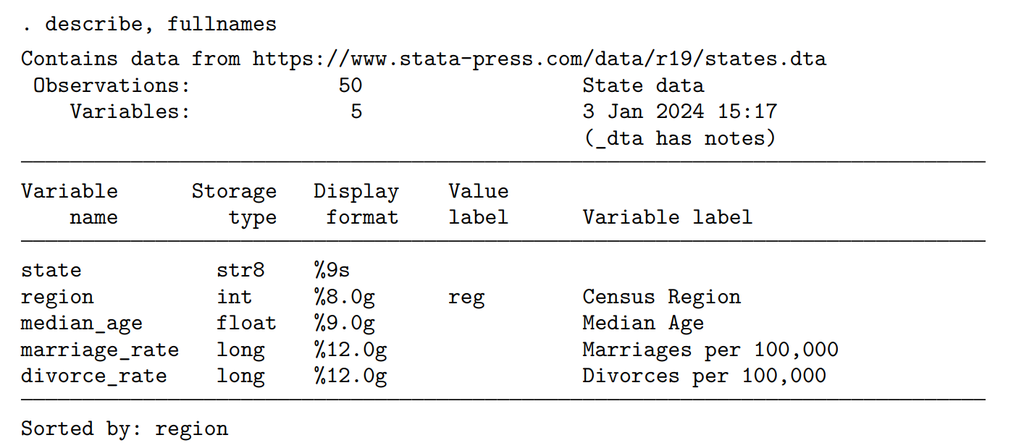

Example of Stata output that includes variable labels

### Labelled data

There are two useful R packages for managing labels:

- [`haven`](https://haven.tidyverse.org/index.html) is used for data import and allows variables to include these labels as extra attributes.
- [`labelled`](https://larmarange.github.io/labelled/articles/labelled.html) provides further support and convenience functions for working with labelled data.

### Labelled data

- The `label` here is a variable label that provides more detail on the variable itself.
- The `labels` attribute contains value labels that may contain extra information about the values/responses for that variable.
- By default, many R functions will ignore these attributes.

```r
library(haven)

# importing stata formatted data with haven:
states<-read_dta("https://www.stata-press.com/data/r19/states.dta")

attributes(states$region)
```

```
$label
[1] "Census Region"

$format.stata
[1] "%8.0g"

$class
[1] "haven_labelled" "vctrs_vctr"     "double"

$labels
N. Centr  N. East    South     West
       1        2        3        4
```

```r
# table doesn't recognize the labels here:
table(states$region)
```

```
 1  2  3  4
12  9 16 13
```

### Converting labelled data

- We can convert these to R factors with `haven::as_factor`
- Running `haven::as_factor` without specifying any columns will just convert all of the `haven_labelled` variables to R factors. Alternatively, you can include the name of a variable to only convert one thing at a time.

```r
states<-states|>
  as_factor() # using as_factor on the entire data set

attributes(states$region)
```

```
$levels
[1] "N. Centr" "N. East"  "South"    "West"

$class
[1] "factor"

$label
[1] "Census Region"
```

```r
# now R recognizes the labels:
table(states$region)
```

```
N. Centr  N. East    South     West
      12        9       16       13
```

### Recoding numeric values

You’ll want to be especially careful when using `as_factor` on variables that you might want to treat as numeric.

For instance: “feeling thermometer” type questions like `V242125` range from 0 to 100, so they’re basically numeric, but the ANES data also includes some value labels for non-answers:

```r
print_labels(anes24$V242125)
```

```
Labels:
 value                                       label
    -9                                 -9. Refused
    -7 -7. Insufficient partial, interview deleted
    -6                       -6. No post interview
    -5            -5. Sufficient partial, breakoff
    -1                            -1. Inapplicable
   998             998. Don't know (where to rate)
   999                        999. Don't recognize
```

### Recoding numeric values

So, you’ll get really weird results if you convert them to a factor first:

```r
# converting to a factor, then to numeric:
anes24$V242125|>
  as_factor()|>
  as.numeric()|>
  summary()
```

```
   Min. 1st Qu.  Median    Mean 3rd Qu.    Max.
   1.00    6.00   25.00   28.51   50.00   65.00
```

And you’ll also get weird results from converting directly to numeric:

```r
# converting to numeric without changes:
anes24$V242125|>
  as.numeric()|>
  summary()
```

```
   Min. 1st Qu.  Median    Mean 3rd Qu.    Max.
  -9.00    0.00   40.00   41.87   80.00  999.00
```

### Recoding numeric values

A good approach here is to use `case_when` to convert to numeric and then recode values lower than zero as `NA`:

```r
harris_therm<-case_when(as.numeric(anes24$V242125) <0| as.numeric(anes24$V242125)>100 ~ NA,
            .default = as.numeric(anes24$V242125)
            )

summary(harris_therm)
```

```
   Min. 1st Qu.  Median    Mean 3rd Qu.    Max.    NA's
   0.00    5.00   50.00   47.33   85.00  100.00     636
```

### Missing values and recoding

Many survey formats will include multiple kinds of non-answer responses (Refused vs. Inapplicable vs. Don’t know, for instance). Sometimes the distinction is important for analysts, but in many cases we don’t care:

```r
# Is R registered to vote?
reg_vote<-anes24$V241012

print_labels(reg_vote)
```

```
Labels:
 value            label
    -9      -9. Refused
    -8   -8. Don't know
    -1 -1. Inapplicable
     1           1. Yes
     2            2. No
```

### Missing values and recoding

There are several options for how you might handle these non-answers:

Converting with `as_factor` and leaving non-answers alone:

```r
reg_vote|>
  as_factor()|>
  table()
```

```
     -9. Refused   -8. Don't know -1. Inapplicable           1. Yes
               2                2              273             4855
           2. No
             389
```

Converting to a regular R factor and then just leaving out the missing codes (which will make them all `NA` values)

```r
factor(reg_vote, levels=c(1, 2),
       labels=c("Yes", "No"))|>
  table()
```

```
 Yes   No
4855  389
```

Converting with `as_factor` and dropping non-answers using `fct_recode`:

```r
reg_vote|>
  as_factor()|>
  fct_recode(NULL ='-9. Refused',
             NULL = "-8. Don't know",
             NULL = "-1. Inapplicable")|>
  table()
```

```
1. Yes  2. No
  4855    389
```

Converting with `as_factor()` and creating a combined category for invalid responses:

```r
reg_vote|>
  as_factor()|>
  fct_recode("DK/NA/REF" ='-9. Refused',
             "DK/NA/REF" = "-8. Don't know",
             "DK/NA/REF" = "-1. Inapplicable")|>
  table()
```

```
DK/NA/REF    1. Yes     2. No
      277      4855       389
```

Using `case_when` with something like `str_detect` to create a combined category

```r
case_when(str_detect(reg_vote, "^-") ~ "DK/NA/REF",
          .default = as_factor(reg_vote)
          )|>
  # convert back to a factor
  factor()|>
  # Put DK/NA/REF as the first category:
  fct_relevel("DK/NA/REF")|>
  table()
```

```
DK/NA/REF    1. Yes     2. No
      277      4855       389
```

### Missing values and recoding

Similar scenarios arise when you just want to collapse or combine categories:

```r
marital<-anes24$V241459
print_labels(marital)
```

```
Labels:
 value                                label
    -9                          -9. Refused
    -1                     -1. Inapplicable
     1           1. Married: spouse present
     2 2. Married: spouse absent {VOL, FtF}
     3                           3. Widowed
     4                          4. Divorced
     5                         5. Separated
     6                     6. Never married
```

### Missing values and recoding

`case_when` can also be helpful here:

```r
case_when(
          str_detect(marital, "^-") ~ "DK/NA/REF",
          marital %in% c(1, 2) ~ "Married",
          marital %in% c(3:6) ~ "Not currently Married")|>
  # make Don't know the baseline category:
  fct_relevel("DK/NA/REF")|>
  table()
```

```
            DK/NA/REF               Married Not currently Married
                  258                  2745                  2518
```

### Missing values and recoding

Always check your new values against the old variables and make sure things align with your intentions! Using the `distinct` function can be helpful here:

```r
anes24|>

  mutate(
    marital_factor = as_factor(V241459),
    marital_recode = case_when(str_detect(V241459, "^-") ~ "DK/NA/REF",
          V241459 %in% c(1, 2) ~ "Married",
          V241459 %in% c(3:6) ~ "Not currently Married")|>
      fct_relevel("DK/NA/REF")
)|>
  distinct( V241459, marital_factor, marital_recode)
```

```
# A tibble: 8 × 3
  V241459                                   marital_factor        marital_recode
  <dbl+lbl>                                 <fct>                 <fct>
1  1 [1. Married: spouse present]           1. Married: spouse p… Married
2  3 [3. Widowed]                           3. Widowed            Not currently…
3  4 [4. Divorced]                          4. Divorced           Not currently…
4  6 [6. Never married]                     6. Never married      Not currently…
5  5 [5. Separated]                         5. Separated          Not currently…
6 -9 [-9. Refused]                          -9. Refused           DK/NA/REF
7 -1 [-1. Inapplicable]                     -1. Inapplicable      DK/NA/REF
8  2 [2. Married: spouse absent {VOL, FtF}] 2. Married: spouse a… Married
```

### Try it out

1. Try creating a collapsed three-level measure from `V241075x` that combines the Democratic vote/intent/preference, Republican vote/intent/preference, and other vote/intent preference responses into single categories and sets all other variables to `NA` values.
2. Recode the pre-election (`V241157`) and post-election (`V242126`) feeling thermometers for Donald Trump to numeric. Make sure you convert don’t know/refused responses to `NA` values.
3. Create a variable called `trump_therm_diff` that is the result for the post-election thermometer minus the pre-election thermometer.

**View code**

```r
anes24<-anes24 |>
  mutate(pres_pref= as_factor(V241075x),
         pres_pref = case_when(
           str_detect(pres_pref, "Democratic candidate")  ~ "Democratic candidate",
           str_detect(pres_pref, "Republican candidate")  ~ "Republican candidate",
           str_detect(pres_pref, "Other candidate") ~ "Other candidate")|>factor(),

         trump_therm_pre = case_when(as.numeric(V241157) < 0 | as.numeric(as.numeric(V241157))>100 ~ NA,
                                     .default = as.numeric(V241157)),
         trump_therm_post = case_when(as.numeric(V242126) < 0 | as.numeric(V242126)>100  ~ NA,
                                     .default = as.numeric(V242126)),

         trump_therm_diff = trump_therm_post - trump_therm_pre

  )
# Checking results:
anes24|>
  distinct(pres_pref, as_factor(V241075x))|>
  arrange(pres_pref)
summary(anes24$trump_therm_post)
summary(anes24$trump_therm_pre)
```

# Analysis

- Analyses of survey results often require special consideration of the ways that the sample differs from the target population due to the sampling strategy, non-response, or random chance.
- Most importantly: you’ll usually need to incorporate survey weights before you can generalize most survey data.
- We’ll briefly discuss how this applies to the ANES before we get into the coding…

### Base weights

- Adjusting for the stratification is (comparatively) easy. If my sampling frame gives Californians a 4-fold greater chance of being sampled, then each respondent would be given 1/4th the normal weight in the analysis.
- We can do this before we even send out the survey because its entirely a function of the sampling design.

### Post-stratification

Even after correcting for stratification, our sample might differ from the population by random chance or because of systematic non-response.

- We might have too many Californians purely by bad luck, or Californians might be more likely to answer the phone than others.
- Fortunately, we could still use inverse weighting here: we know how many Californians exist in the population, and so we can just re-weight to match the known population.

| Group | Population % | Sample % |
| --- | --- | --- |
| **Californians** | $11.7\%$ | $23.4\%$ |
| **Everyone else** | $88.3\%$ | $76.6\%$ |

After weighting:

| Group | Population % | Sample % | Weighted % |
| --- | --- | --- | --- |
| **Californians** | $11.7\%$ | $23.4\%$ | $23.4 \times 0.5 = 11.7\%$ |
| **Everyone else** | $88.3\%$ | $76.6\%$ | $76.6 \times 1.15 = 88.3\%$ |

Post-stratification like this is only possible when we know the population values and the corresponding values for respondents.

### Calibration

- What if Californian women who make under $40,000 a year are twice as likely to answer the phone?
- We might know some marginal totals for *some* of these characteristics, but we almost certainly don’t know the cell values, so we can’t just calculate an inverse probability of selection here.

| Group | Under $40K | Over $40K | Total |
| --- | --- | --- | --- |
| **Californians** | ?? | ?? | 11.7% |
| **Everyone else** | ?? | ?? | 88.3% |
| **Total** | 21% | 79% |  |

- The ANES uses “raking” to address this problem.

### Raking

- Iterative proportional fitting (raking): weight responses to match the *marginal* proportions for each variable separately
  - i.e.: weight for “Californian”, then “income”, then “gender”, then repeat.
  - Weights are typically “trimmed” to avoid giving too much weight to any one observation.

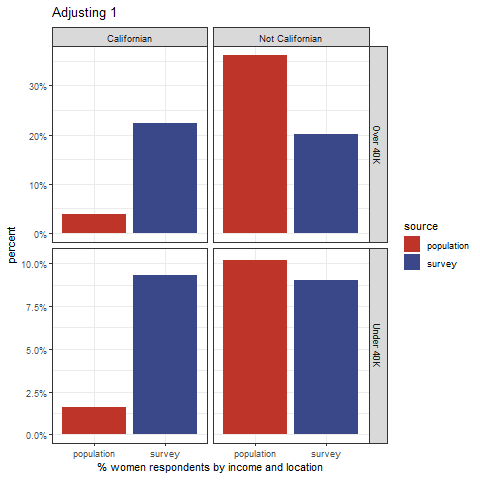

Example of raking some made up data to match a made up target population.

### Weighted and unweighted ANES data

The weight variables on the ANES are the product of design, post-stratification, and calibration weighting - since the non-response and the sampling strategy differ slightly depending on the survey mode, there are multiple potential weights for each respondent.

Weighted and unweighted education for white ANES 2024 respondents

| **Education** | N | Unweighted Percent vs. Weighted Percent |
| --- | --- | --- |
| 1. Less than high school credential | 155 |  |
| 2. High school credential | 652 |  |
| 3. Some post-high school, no bachelor's degree | 1223 |  |
| 4. Bachelor's degree | 1051 |  |
| 5. Graduate degree | 840 |  |

## Using Survey Weights

### Consulting the user guide

- Check out the ANES user guide for information on the weighting variables.
- Note that there’s actually more than one option here! Usually the full-sample weights are fine, but you’ll also want to use post-election weights if you’re using post-election questions.

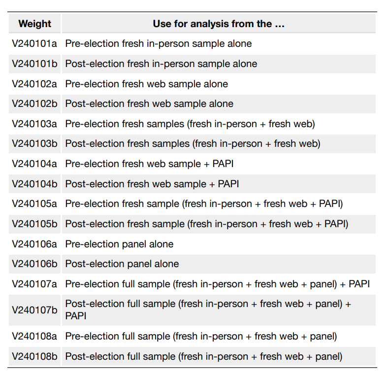

### Calculating a weighted proportion

If you just need a weighted summary statistic, you can just use the weights in place of counting the number of observations:

```r
results<-anes24|>
  select(education =V241465x,
         weight = V240107a)|>
  as_factor()|>
  group_by(education)|>
  summarize(n = n(),
         `weighted n` = sum(weight)
         )|>
  ungroup()|>
  mutate(proportion = n /sum(n),
        `weighted proportion` = `weighted n` / sum(`weighted n`))


# making this look nicer:
results|>
  # dropping non-responses
  filter(!str_detect(education, "^-"))|>
  mutate(percent = sprintf("%0.1f%%",
                           proportion* 100),
         `weighted percent`  = sprintf("%0.1f%%",
                                       `weighted proportion` * 100)
        )|>
  select(-proportion, -`weighted proportion`)|>
  knitr::kable(digits=1)|>
  kableExtra::kable_classic()
```

| education | n | weighted n | percent | weighted percent |
| --- | --- | --- | --- | --- |
| 1. Less than high school credential | 283 | 447.2 | 5.1% | 8.1% |
| 2. High school credential | 973 | 1468.3 | 17.6% | 26.6% |
| 3. Some post-high school, no bachelor's degree | 1738 | 1673.6 | 31.5% | 30.3% |
| 4. Bachelor's degree | 1384 | 1158.4 | 25.1% | 21.0% |
| 5. Graduate degree | 1087 | 722.7 | 19.7% | 13.1% |

### Calculating a weighted proportion

- If you’re doing something more involved than this, you’ll probably want to use a dedicated survey analysis library (especially if you want to include uncertainty estimates)
  - `survey`
  - `srvyr` (tidy-friendly)
- Both have the same general workflow: you’ll convert a data set into a “survey” data set that includes information about the survey design in an attribute, then you’ll use special commands to do things like `survey_mean()` or `svyby()` that automatically calculate weighted statistics.

### Using a library

#### `survey`

```r
library(survey)
svyanes<-svydesign(data = anes24,
                   ids = ~V240107c,    # PSU ID
                   strata=~V240107d,  # Strata ID
                   weight=~V240107a,  # Weights
                   nest=T)            # nests strata in PSUs


attributes(svyanes)
```

```
$names
[1] "cluster"    "strata"     "has.strata" "prob"       "allprob"
[6] "call"       "variables"  "fpc"        "pps"

$class
[1] "survey.design2" "survey.design"
```

#### `srvyr`

```r
library(srvyr)


svyanes<-anes24|>
  as_survey_design(
                   ids = V240107c,    # PSU ID
                   strata=V240107d,  # Strata ID
                   weight=V240107a,  # Weights
                   nest=T)            # nests strata in PSUs

attributes(svyanes)
```

```
$names
[1] "cluster"    "strata"     "has.strata" "prob"       "allprob"
[6] "call"       "variables"  "fpc"        "pps"

$class
[1] "tbl_svy"        "survey.design2" "survey.design"

$survey_vars
Sampling variables:
  - ids: V240107c
  - strata: V240107d
  - weights: V240107a
```

### Using a library

The `survey_prop` function should always be used inside of a call to `summarize` to produce proportions for each level of some grouping variable:

```r
result<-svyanes|>
  group_by(pres_pref)|>
  summarize(p = survey_prop(var = 'ci')
            )|>
  drop_na()


result
```

```
# A tibble: 3 × 4
  pres_pref                 p  p_low  p_upp
  <fct>                 <dbl>  <dbl>  <dbl>
1 Democratic candidate 0.448  0.428  0.468
2 Other candidate      0.0636 0.0541 0.0746
3 Republican candidate 0.401  0.382  0.420
```

### Using a library: two-way proportions

We can also get these results for a two way table. The default behavior for `survey_prop` will give us proportions that sum to one for the variable that’s listed first in `group_by`:

```r
twoway_result<-svyanes|>
  mutate(reg_vote =
    fct_recode(as_factor(V241012),
               "DK/NA/REF" ='-9. Refused',
               "DK/NA/REF" = "-8. Don't know",
               "DK/NA/REF" = "-1. Inapplicable"))|>
  group_by(pres_pref, reg_vote)|>
  summarize(p = survey_prop(var = 'ci')
            )|>
  drop_na()

twoway_result
```

```
# A tibble: 9 × 5
  pres_pref            reg_vote       p  p_low  p_upp
  <fct>                <fct>      <dbl>  <dbl>  <dbl>
1 Democratic candidate DK/NA/REF 0.0353 0.0266 0.0466
2 Democratic candidate 1. Yes    0.918  0.899  0.933
3 Democratic candidate 2. No     0.0470 0.0347 0.0634
4 Other candidate      DK/NA/REF 0.0380 0.0201 0.0706
5 Other candidate      1. Yes    0.845  0.779  0.894
6 Other candidate      2. No     0.117  0.0723 0.184
7 Republican candidate DK/NA/REF 0.0647 0.0438 0.0945
8 Republican candidate 1. Yes    0.860  0.828  0.886
9 Republican candidate 2. No     0.0758 0.0600 0.0953
```

### Using a library: means

`survey_mean` works the same way for continuous variables:

```r
svyanes |>
  mutate(
    harris_therm = case_when(
      as.numeric(anes24$V242125) < 0 |
        as.numeric(anes24$V242125) > 100 ~ NA,
      .default = as.numeric(anes24$V242125)
    )) |>
      group_by(pres_pref) |>
      summarise(harris_mean = survey_mean(harris_therm, var = 'ci', na.rm=T)
      )
```

```
# A tibble: 4 × 4
  pres_pref            harris_mean harris_mean_low harris_mean_upp
  <fct>                      <dbl>           <dbl>           <dbl>
1 Democratic candidate        77.2            76.1            78.2
2 Other candidate             35.0            30.1            39.9
3 Republican candidate        15.5            14.0            16.9
4 <NA>                        40.3            35.8            44.8
```

### Using a library: tables

We can also use a library like [GT](https://gt.rstudio.com/) to show a table of these results:

```r
library(gt)
gt(result)|>
  fmt_percent()|>
  cols_label(pres_pref = "Preferred Candidate",
             p = "Weighted %",
             p_low = "Lower 95% CI",
             p_upp ="Upper 95% CI"
             )
```

| Preferred Candidate | Weighted % | Lower 95% CI | Upper 95% CI |
| --- | --- | --- | --- |
| Democratic candidate | 44.77% | 42.78% | 46.77% |
| Other candidate | 6.36% | 5.41% | 7.46% |
| Republican candidate | 40.06% | 38.15% | 41.99% |

### Using a library: tables

We can also use a library like [GT](https://gt.rstudio.com/) to show a table of these results:

```r
library(gt)


gt(twoway_result)|>
  fmt_percent()|>
  cols_label(pres_pref = "Preferred Candidate",
             p = "Weighted %",
             p_low = "Lower 95% CI",
             p_upp ="Upper 95% CI"
             )
```

| PRE: Is R registered to vote | Weighted % | Lower 95% CI | Upper 95% CI |
| --- | --- | --- | --- |
| Democratic candidate |  |  |  |
| DK/NA/REF | 3.53% | 2.66% | 4.66% |
| 1. Yes | 91.77% | 89.94% | 93.30% |
| 2. No | 4.70% | 3.47% | 6.34% |
| Other candidate |  |  |  |
| DK/NA/REF | 3.80% | 2.01% | 7.06% |
| 1. Yes | 84.49% | 77.90% | 89.39% |
| 2. No | 11.71% | 7.23% | 18.41% |
| Republican candidate |  |  |  |
| DK/NA/REF | 6.47% | 4.38% | 9.45% |
| 1. Yes | 85.96% | 82.81% | 88.60% |
| 2. No | 7.58% | 6.00% | 9.53% |

### Using a library: tables

Or we can use the `gtsummary` package, which has some built-in methods for plotting data from a `survey.design` object:

```r
library(gtsummary)

svyanes|>
  select(pres_pref)|>
  tbl_svysummary(
     label = list(pres_pref = "Candidate Preference"),
  )
```

| **Characteristic** | **N = 5,521**<sup>1</sup> |
| --- | --- |
| Candidate Preference |  |
| Democratic candidate | 2,472 (49%) |
| Other candidate | 351 (7.0%) |
| Republican candidate | 2,211 (44%) |
| Unknown | 487 |

<sup>1</sup> n (%)

### Using a library: tables

We can also use this to make a crosstab:

```r
svyanes|>
  mutate(marital_status = as_factor(V241461x))|>

  select(pres_pref, marital_status)|>
  tbl_svysummary(by = marital_status,
                label = list(pres_pref = "Candidate Preference")
                 )
```

| **Characteristic** | **-2. Missing in V241459 or V241460** N = 20<sup>1</sup> | **1. Married** N = 2,824<sup>1</sup> | **2. Widowed** N = 320<sup>1</sup> | **3. Divorced** N = 626<sup>1</sup> | **4. Separated** N = 88<sup>1</sup> | **5. Never married** N = 1,643<sup>1</sup> |
| --- | --- | --- | --- | --- | --- | --- |
| Candidate Preference |  |  |  |  |  |  |
| Democratic candidate | 4 (39%) | 1,197 (45%) | 157 (53%) | 296 (51%) | 38 (49%) | 779 (54%) |
| Other candidate | 3 (25%) | 167 (6.3%) | 10 (3.3%) | 52 (9.1%) | 6 (7.3%) | 113 (7.9%) |
| Republican candidate | 4 (35%) | 1,269 (48%) | 131 (44%) | 229 (40%) | 34 (44%) | 544 (38%) |
| Unknown | 9 | 191 | 22 | 48 | 11 | 206 |

<sup>1</sup> n (%)

### Using a library: plots

Or we could use `ggplot` to turn the result into a bar plot:

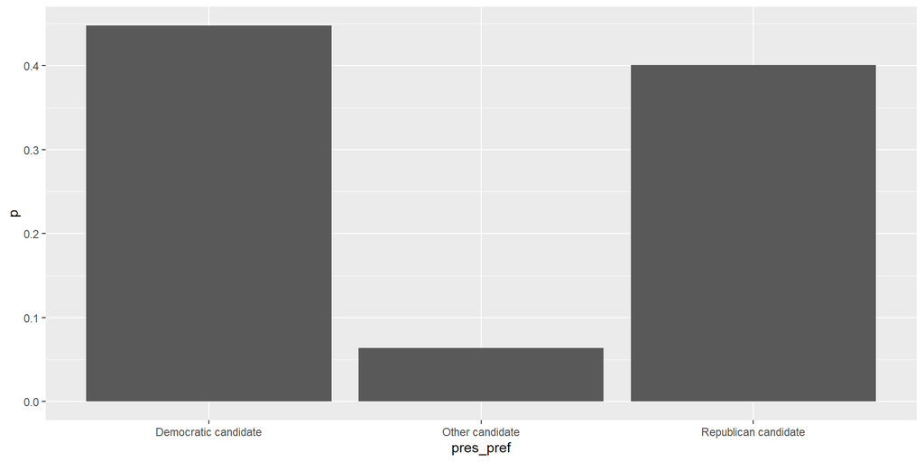

```r
ggplot(result, aes(x=pres_pref, y=p)) +
  geom_bar(stat='identity')
```

### Using a library: plots

We can improve the look a bit here

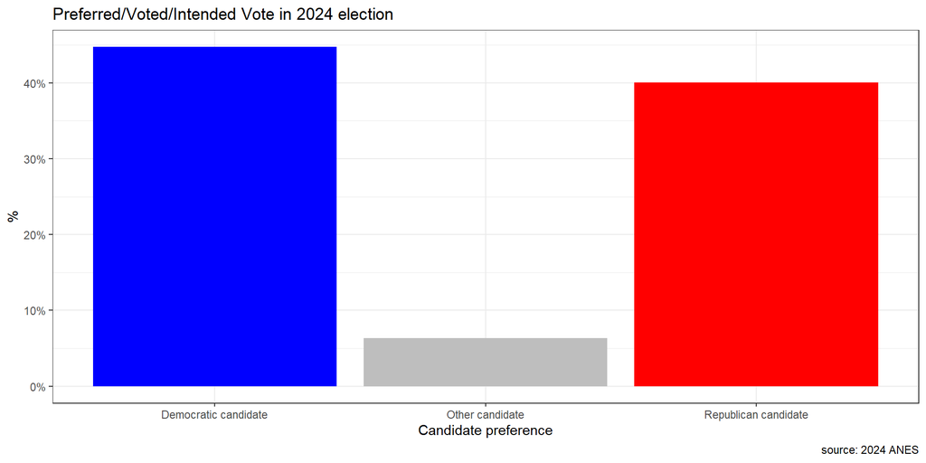

```r
ggplot(result, aes(x=pres_pref, y=p, fill = pres_pref)) +
  geom_bar(stat='identity') +
  scale_y_continuous(labels = scales::percent) +
  labs(x='Candidate preference',
       y='%',
       title ='Preferred/Voted/Intended Vote in 2024 election',
       caption ='source: 2024 ANES'
       ) +
  theme_bw() +
  guides(fill='none') +
  scale_fill_manual(values=c('blue','grey','red'))
```

### Using a library: plots

And we can make use of the 95% confidence intervals to give a sense of the uncertainty surrounding these estimates:

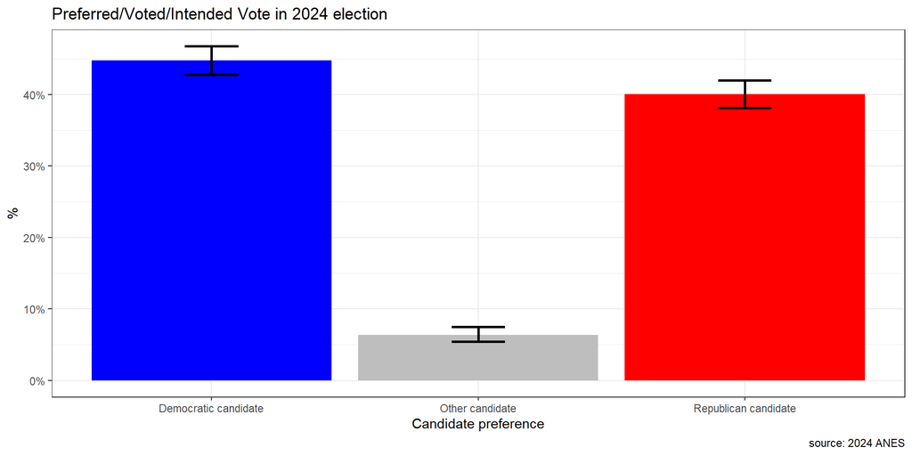

```r
ggplot(result, aes(x=pres_pref, y=p, fill = pres_pref)) +
  geom_bar(stat='identity') +
  geom_errorbar(aes(ymin=p_low, ymax=p_upp), width=.2, size=1) +
  scale_y_continuous(labels = scales::percent) +
  labs(x='Candidate preference',
       y='%',
       title ='Preferred/Voted/Intended Vote in 2024 election',
       caption ='source: 2024 ANES'
       ) +
  theme_bw() +
  guides(fill='none') +
  scale_fill_manual(values=c('blue','grey','red'))
```

### Try it out

[The ANES User guide for 2024](https://electionstudies.org/wp-content/uploads/2025/08/anes_timeseries_2024_userguidecodebook_20250808.pdf) recommends using the post election weights any time a post election question is included in an analysis.

1. Consult the tables on page 12/13 to find the appropriate weights, PSU, and stratum variables for the full post-election sample (including PAPI). Then, use `srvyr` to declare the design characteristics of the data for use with post-election questions. Note: the post election weights are missing for some respondents. You’ll need to drop these cases before the `as_survey_design` function will work.
2. Did people who voted against Trump feel more warmly towards him after he won the election? Use `group_by` and `survey_mean` to analyze differences in `trump_therm_diff` across different candidate preferences.

```r
svyanes_post<-anes24|>
  filter(!is.na(V240107b))|> # Remove missing
  as_survey_design(
    ids = V240107c,    # PSU ID
    strata=V240107d,  # Strata ID
    weight=V240107b,  # Weights
    nest=T)



pref_diff<-svyanes_post|>
  group_by(pres_pref)|>
  summarize(
            trump_therm_diff = survey_mean(trump_therm_diff, vartype='ci',  na.rm=T),

            )
```

### Extra code: plotting results

Since this result includes a confidence interval, we can use a `errorbar` plot to show the results:

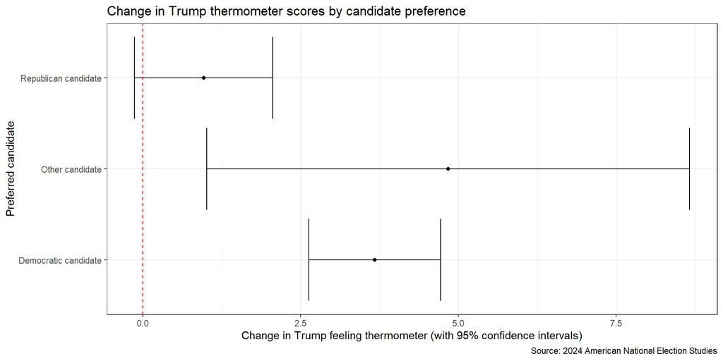

```r
pref_diff|>
  drop_na()|>
  ggplot( aes(x=pres_pref, y=trump_therm_diff)) +
  geom_point() +
  geom_errorbar(aes(ymin =  trump_therm_diff_low, ymax=trump_therm_diff_upp)) +
  theme_bw() +
  coord_flip() +
  geom_hline(yintercept = 0, col='red', lty=2) +
  labs(x="Preferred candidate",
       y="Change in Trump feeling thermometer (with 95% confidence intervals)",
       title = "Change in Trump thermometer scores by candidate preference",
       caption = "Source: 2024 American National Election Studies"
    )
```

### Extra code: plotting results

We can also do something fancier here using the original data and the `ggdist` package. While this doesn’t show the weighted mean or confidence interval, it arguably does just as well at conveying the general trends:

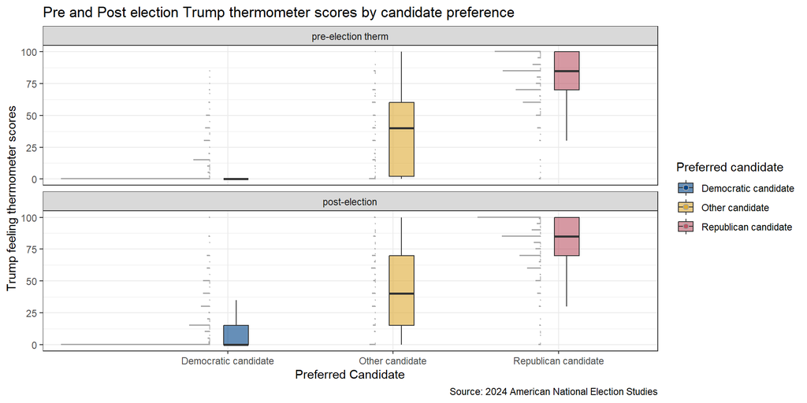

```r
library(ggdist)
anes24|>
  drop_na(pres_pref)|>
  select(trump_therm_pre, trump_therm_post, V240107b, pres_pref, V240001)|>
  group_by(pres_pref)|>
  pivot_longer(cols=c(trump_therm_post, trump_therm_pre), names_to='pre_post', values_to='therm' ) |>
  mutate(pre_post = fct_recode(pre_post,
                               "pre-election therm" = "trump_therm_pre",
                               "post-election" = "trump_therm_post"
                               )|>fct_relevel("pre-election therm"))|>
  drop_na()|>
  ggplot(aes(y=therm, x=pres_pref, weight=V240107b,  fill=pres_pref)) +
  stat_boxplot(width = 0.15,
               outliers=FALSE,
               alpha = 0.6,
               position = position_nudge(x = 0.05, y = 0))+
  facet_wrap(~pre_post, ncol=1) +
  stat_dots(side='left', justification=1.12,
            binwidth=1,
            dotsize=.1,
            overflow='compress',
            overlaps='nudge',
            layout='swarm') +
  theme_bw() +
  paletteer::scale_fill_paletteer_d("khroma::highcontrast") +
  labs(y = "Trump feeling thermometer scores",
       x="Preferred Candidate",
       fill = 'Preferred candidate',
       caption = "Source: 2024 American National Election Studies",
       title = "Pre and Post election Trump thermometer scores by candidate preference"
       )
```

### Extra code: formatting a table

Finally, we can use `gt` and `gtExtra` to create a nicely formatted table from our results.

```r
library(gt)
library(gtExtras)

pref_diff|>
  drop_na()|>
  gt()|>
  fmt_number(decimals=2)|>
  cols_label(pres_pref = "Pre-election vote/intent/preference",
             trump_therm_diff = "Change in feeling  thermometer for Trump",
             trump_therm_diff_low = "Lower 95% CI",
             trump_therm_diff_upp = "Upper 95% CI"
             )
```

| Pre-election vote/intent/preference | Change in feeling thermometer for Trump | Lower 95% CI | Upper 95% CI |
| --- | --- | --- | --- |
| Democratic candidate | 3.67 | 2.63 | 4.72 |
| Other candidate | 4.84 | 1.01 | 8.66 |
| Republican candidate | 0.96 | −0.13 | 2.06 |

### Extra code: formatting a table

We can go one step further and add an inline confidence interval and point estimate:

```r
pref_diff|>
  drop_na()|>
  gt()|>
  fmt_number(decimals=2)|>
  cols_label(pres_pref = "Pre-election vote/intent/preference",
             trump_therm_diff = "Change in feeling  thermometer for Trump",
             trump_therm_diff_low = "Lower 95% CI",
             trump_therm_diff_upp = "Upper 95% CI"
             )|>
  gt_plt_conf_int(column = trump_therm_diff,
                  ci_columns = c(trump_therm_diff_low, trump_therm_diff_upp ),
                  ref_line = 0)
```

| Pre-election vote/intent/preference | Change in feeling thermometer for Trump | Lower 95% CI | Upper 95% CI |
| --- | --- | --- | --- |
| Democratic candidate |  | 2.63 | 4.72 |
| Other candidate |  | 1.01 | 8.66 |
| Republican candidate |  | −0.13 | 2.06 |